# Length to Lipids conversion.V2

P. Santiago Domínguez-Sánchez

2025

### Calculating lengths at ‘RMIS region - Brood year - Age’ level

```r
length_ref_val <- read_xlsx(here("R","data","GAM_reference_values_v2.xlsx"))
head(length_ref_val)
```

```
## # A tibble: 6 × 3
##   region   age ref_mean
##   <chr>  <dbl>    <dbl>
## 1 CECR       1     612.
## 2 CECR       2     707.
## 3 CECR       3     839.
## 4 CECR       4     918.
## 5 CECR       5     906.
## 6 FRTH       1     622.
```

```r
gam_predictions  <- read_xlsx(here("R","data","GAM_predictions_v2.xlsx"))
head(gam_predictions)
```

```
## # A tibble: 6 × 7
##   region   age  year   fit se.fit ref_mean rel_pred
##   <chr>  <dbl> <dbl> <dbl>  <dbl>    <dbl>    <dbl>
## 1 CECR       1  1980  600.  10.1      612.    -1.97
## 2 CECR       1  1981  599.   8.89     612.    -2.15
## 3 CECR       1  1982  598.   7.85     612.    -2.34
## 4 CECR       1  1983  597.   6.99     612.    -2.52
## 5 CECR       1  1984  595.   6.31     612.    -2.71
## 6 CECR       1  1985  594.   5.78     612.    -2.91
```

```r
colnames(gam_predictions)[2:3] <- c("ocean_age","brood_year")
```

### Size at age and region

| region | brood_year | 1 | 2 | 3 | 4 | 5 |
| --- | --- | --- | --- | --- | --- | --- |
| CECR | 2008 | 614.2402 | 706.8939 | 833.1406 | 906.2313 | NA |
| CECR | 2009 | 615.5813 | 706.5605 | 828.6538 | 898.1454 | NA |
| CECR | 2010 | 616.9442 | 706.2197 | 824.0969 | 889.9786 | NA |
| FRTH | 1980 | 567.1555 | 673.5965 | 845.8200 | 973.8004 | NA |
| FRTH | 1981 | 569.8844 | 674.9115 | 847.4117 | 971.4304 | NA |
| FRTH | 1982 | 572.5491 | 676.2243 | 849.0288 | 969.2066 | NA |
| FRTH | 1983 | 575.1021 | 677.5355 | 850.6648 | 967.1893 | NA |
| FRTH | 1984 | 577.4986 | 678.8474 | 852.3196 | 965.4479 | NA |
| FRTH | 1985 | 579.7072 | 680.1636 | 853.9999 | 964.0508 | NA |
| FRTH | 1986 | 581.7178 | 681.4891 | 855.7181 | 963.0560 | NA |
| FRTH | 1987 | 583.5443 | 682.8299 | 857.4908 | 962.5046 | NA |

In this case, the NAs belonging to the CECR 2008-2010 and FRTH 1980 - 1987 at age 5 are due to the ‘rel_pred’ and ‘reference size’ value being missing at this age.

Let’s check where the NAs are

```r
print(NA_size_at_age)
```

```
## # A tibble: 22 × 2
## # Groups:   region [21]
##    region ocean_age
##    <chr>      <dbl>
##  1 CECR           5
##  2 FRTH           5
##  3 GRAY           1
##  4 GRAY           5
##  5 GST            5
##  6 HOOD           5
##  7 JNST           5
##  8 JUAN           5
##  9 KLTR           5
## 10 LOCR           5
## # ℹ 12 more rows
```

All regions have at least one missing value at ‘age-5’, and only the ‘GRAY’ region has missing values at ages 1 and 5. Since the FRAM abundance database does not contain information for age 1, the missing values at ‘age-1’ will not be relevant in the next calculations.

But before filling the NAs, let’s see how the data looks so far.

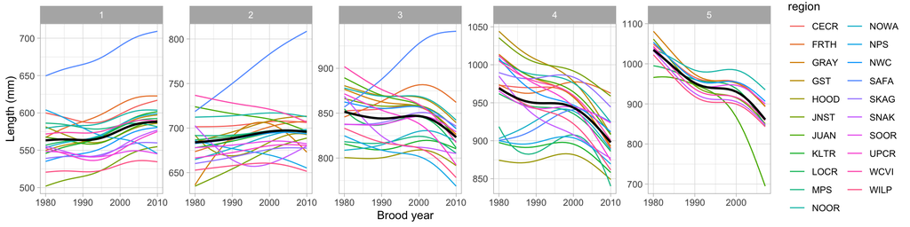

**2)** For the years for age 5 without the ‘fitted lengths’, ‘se fitted lengths’, ‘reference means’ and “rel_pred”, the values were taken relative to age 4.

```r
full_gam_predictions <- check.grid%>%
  left_join(gam_predictions, by = c("region","brood_year","ocean_age"))%>%
  group_by(region, ocean_age)%>%
  arrange(region,ocean_age)%>%
  fill(fit, se.fit, ref_mean, rel_pred, .direction = 'down')%>% #Fill NAs under assumption 1
  ungroup()%>%
  group_by(region, brood_year)%>%
  arrange(region,brood_year)%>%
  fill(fit, se.fit, ref_mean, rel_pred, .direction = 'down')%>% #Fill NAs under assumption 2
  ungroup()

avg_size_at_year <- full_gam_predictions%>%
  group_by(ocean_age,brood_year)%>%
  summarise(avg.size = mean(fit, na.rm = TRUE))%>%
  ungroup()
```

*Chinook salmon size over brood year - Each line is a region and color indicates ocean age*

[figure not shown]

*Chinook salmon size changes divided by ocean age - Color indicates region and black line is the mean size trend for each age*

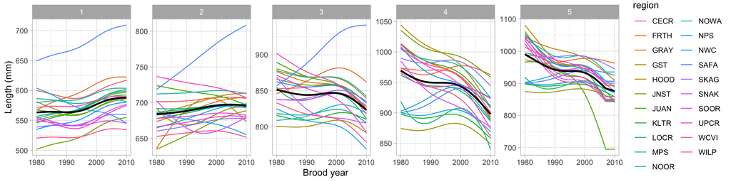

*Size changes over brood year for each region - Color indicates ocean age*

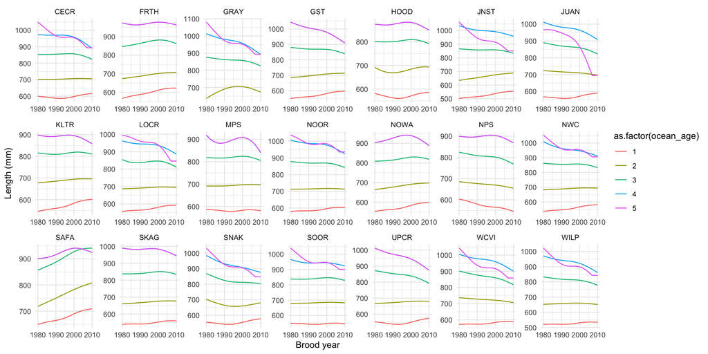